# Converting regression parameters from linear logistic models using only summary statistics

# Introduction

Many traits that we might like to include in the basis are continuous and therefore we only have access to published summary statistics for a linear regression of the form
$$Y = \alpha + \beta X + \epsilon$$
.

We therefore need a method to convert linear regression summary statistics from these studies to their logistic regression counterparts including log(OR) or $\beta$ coefficients and it’s standard error - $\sigma_{\beta}$. The code below first simulates some continuous and allelic data for a single biallelic SNP with various known parameters. We then fit a linear model and use this to estimate parameters. Next we dichotomise the trait by grouping those individuals whom $Y > \bar{y}$ and then fit a logistic model to estimate $\beta$ and $\sigma_{\beta}$.

Next we assume that genotype and trait data is unavailable but that we have access to population allele frequency data for the SNP (MAF), N the sample size, $\beta$ the linear regression coefficient it standard error $\sigma_{\beta}$. We then demonstrate that these are suffcient to compute $\bar{x}$ and $\bar{y}$ an estimate of the standard error of $\epsilon$ or $\sigma_{\epsilon}$. We compare these values to their empirical counterparts to validate the method.

Using a mixed model frame work we then use these to estimate the log(OR) or $beta$ coefficient and associated standard error. We validate these metrics against the parameters obtained from our logistic regression fit where we had access to the genotype and trait values.

# Method/Results

## Simulation setup

```r
library(ggplot2)
set.seed(666)
N<-10000
maf<-0.1
beta<-0.4
p.val<-5e-8
beta.se<-beta/abs(qnorm(p.val/2))
```

Here we simulate a continuous trait with slope $\beta=$ 0.4 in a sample size of $N=$ 10^{4} in a single biallelic SNP with maf$=$ 0.1. This implies a $\sigma_{\beta}=$ 0.073 at the significance level of $5\times 10^{-8}$.

```r
#simulate genotypes
X<-rbinom(N,2,maf)
Xbar<-mean(X)
se.e<-beta.se * sqrt(sum((X-Xbar)^2))
#simulate y for a given beta and s
Y=X*beta+rnorm(N,mean=0,sd=se.e)
```

## Plot data with linear regression fit

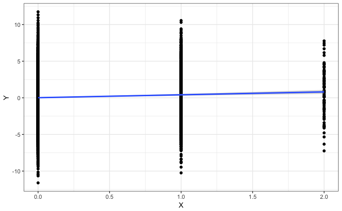

```r
ggplot(data.frame(x=X,y=Y),aes(x=X,y=Y)) + geom_point()  +
    geom_smooth(method='lm',formula=y~x) + theme_bw()
```

## Coefficients of the linear model

```r
mod<-lm(Y~X)
summary(mod)
```

```
Call:
lm(formula = Y ~ X)

Residuals:
     Min       1Q   Median       3Q      Max
-11.6285  -2.0678   0.0346   2.0804  11.7230

Coefficients:
            Estimate Std. Error t value Pr(>|t|)
(Intercept)  0.02165    0.03425   0.632    0.527
X            0.39480    0.07299   5.409 6.47e-08 ***
---
Signif. codes:  0 ‘***’ 0.001 ‘**’ 0.01 ‘*’ 0.05 ‘.’ 0.1 ‘ ’ 1

Residual standard error: 3.088 on 9998 degrees of freedom
Multiple R-squared:  0.002918,  Adjusted R-squared:  0.002818
F-statistic: 29.26 on 1 and 9998 DF,  p-value: 6.473e-08
```

## Coefficients for the logistic model

```r
Yb<-ifelse(Y>mean(Y),1,0)
lmod<-glm(Yb~X,family="binomial")
summary(lmod)
```

```
Call:
glm(formula = Yb ~ X, family = "binomial")

Deviance Residuals:
    Min       1Q   Median       3Q      Max
-1.3821  -1.1639   0.9857   1.1909   1.1909

Coefficients:
            Estimate Std. Error z value Pr(>|z|)
(Intercept) -0.03183    0.02219  -1.434    0.152
X            0.25053    0.04766   5.257 1.47e-07 ***
---
Signif. codes:  0 ‘***’ 0.001 ‘**’ 0.01 ‘*’ 0.05 ‘.’ 0.1 ‘ ’ 1

(Dispersion parameter for binomial family taken to be 1)

    Null deviance: 13862  on 9999  degrees of freedom
Residual deviance: 13834  on 9998  degrees of freedom
AIC: 13838

Number of Fisher Scoring iterations: 3
```

## Computing log(OR) using summary stats from linear model

First estimate $\bar{x}$ using just maf, and sample size.

```r
raf<-1-maf
## Brute force
wtscore<-function(N,r,w=0) N * r^2 * w
hetscore<-function(N,r,w=1) 2 * N * r * (1-r) * w
homscore<-function(N,r,w=2) N * (1-r)^2 *w
estXbarHat<-(wtscore(N,raf) + hetscore(N,raf) + homscore(N,raf))/N
## if we do the algebra then xbarhat simplifies to 2 * (1-raf) or 2 * maf
XbarHat<-2*maf
```

Actual sample $\bar{x}$ is 0.2, from brute force 0.2 and from simplification 0.2. So far so good.

Next estimate $\bar{y}$, which I think is the value of $Y|X=\bar{x}$ or $\hat{y} = \beta \bar{x}$

```r
YbarHat<-beta * XbarHat
```

Actual sample $\bar{y}$ is 0.1 our estimate is 0.08.

For interest want to check that
$$\bar{y} = E(y) = \sum_i E(Y|X_i)P(X_i)$$
i.e
$$\bar{y} = \frac{\beta(N_{\text{het}} + 2N_{\text{hom}})}{N}$$

```r
n.wt<-wtscore(N,raf,1)
n.het<-hetscore(N,raf,1)
n.hom<-homscore(N,raf,1)
estYbar<-(beta * (n.het + (2 * n.hom)))/N
```

Using this method the estimated value of $\bar{y}$ is 0.08.

Next we want to estimate the sum of squares for X (SSX) or $\sum_i (X_i-\bar{x})^2$

```r
SSX.wt<-sum(n.wt * XbarHat^2)
SSX.het<-sum((rep(1,n.het)-rep(XbarHat,n.het))^2)
SSX.hom<-sum((rep(2,n.hom)-rep(XbarHat,n.hom))^2)
SSXHat=SSX.wt + SSX.het + SSX.hom
```

Actual sample SSX is 1789.91 estimate is 1796.12. Looking good !

An alternative method other than brute force for computing SSX is derived from the fact that
$$SSX = (N-1)\sigma_{X}^2$$
which simplifies to
$$SSX = 2\hat{m}(N-1)(1-\hat{m})$$
Let’s check this result.

```r
estSSXHat = 2 * maf * (N-1) * (1-maf)
```

The estimate of SSX this way is 1799.82. Slight difference between brute force, but that could be numerical errors in brute force method.

Next compute $\hat{\sigma_{\epsilon}}$ that is our estimate of the standard error for $\epsilon$. We compute this using the the given value of $\sigma_{\beta}$. As we know that $\sigma_{\epsilon} = \sigma_{\beta} \times \sqrt{\sum_i (X_i-\bar{x})^2}$. We have estimated SSX above and so have all we need.

```r
se.eHat<-beta.se * sqrt(estSSXHat)
```

The actual value of $\sigma_{\epsilon}$ is 3.1 our estimated value is 3.1. Looking good !

Next we need to estimate the Odds of $(Y>\bar{y} | X = x)$ we can then compute the OR as $\frac{Odds(Y>\bar{y} | X = 1)}{Odds(Y>\bar{y} | X = 0)}$

```r
## next estimate P(Y>ybar | X =x)

calcP<-function(X,beta,SE.epsilon,val=YbarHat){
    pnorm(val,mean=X*beta,sd=SE.epsilon,lower.tail = FALSE)
}

calcOdds<-function(X,beta,SE.epsilon,val=YbarHat){
    #num<-pnorm(val,mean=X*beta,sd=SE.epsilon,lower.tail = FALSE)
    num<-calcP(X,beta,SE.epsilon,val)
    num/(1-num)
}

lod_Y_X1<-log(calcOdds(1,beta,se.eHat))
lod_Y_X0<-log(calcOdds(0,beta,se.eHat))

lodHat<-lod_Y_X1-lod_Y_X0
## get estimated log(OR) from fit
fitLod<-summary(lmod)[["coefficients"]][,1][2]
```

Actual log(OR) or $\beta$ from logistic regression fit is 0.25 our estimate is 0.21.

Finally attempt to compute the standard error or $\sigma_{\beta}$ for our $\hat{\beta}$

$$\sigma_{\beta} = \sqrt{\frac{1}{\text{ploidy}}}\sqrt[]{\frac{1}{N_0 + N_1}}\sqrt[]{\frac{1}{a} + \frac{1}{b} + \frac{1}{c} + \frac{1}{d}}$$

```r
ca<-function(n0,f){
    n0*(1-f)
}

cb<-function(n0,f){
    n0*f
}

cc<-function(n1,a,b,theta){
    (n1*a)/(a+(b*theta))
}

cd<-function(n1,a,b,theta){
    (n1*b)/(a+(b*theta))
}

gamma_hat_maf<-function(n0,n1,f,theta){
    n<-n0+n1
    a<-ca(n0,f)/n
    b<-cb(n0,f)/n
    c<-cc(n1,a,b,theta)/n
    d<-cd(n1,a,b,theta)/n
    recip.sm<-do.call('cbind',lapply(list(a,b,c,d),function(fi) 1/fi))
    return(sqrt(rowSums(recip.sm)))
}

## compute number of 'cases' i.e. the the number of people with Y>ybar
n.cases<-round(sum(calcP(0,beta,se.eHat) * n.wt,calcP(1,beta,se.eHat) *
                       n.het,calcP(2,beta,se.eHat) *n.hom))
n.controls<-N-n.cases
#this makes sense given that we expect a normal distribution so in
#future can shorcut but N/2 for the special case where we want Y > ybar
## next compute the variance component of beta due to allele freq
ploidy<-2
var_maf<-gamma_hat_maf(n.controls,n.cases,maf,exp(lodHat))
var_ss<-sqrt(1/N)
estSigmaBeta<-sqrt(1/ploidy) * var_maf * var_ss
fitSigmaBeta<-summary(lmod)[['coefficients']][,2][2]
```

From logistic regression fit we estimate $\sigma_{\beta}$ = 0.048 our estimate using just MAF, $\hat{\theta}$ and Sample size is 0.047. Looking good.

Next examine the P value that we get from this compared to the original P

```r
estZ<-lodHat/estSigmaBeta
estP<-2*(pnorm(estZ,lower.tail = FALSE))
```

# Conclusions

Our input p-val was $5\times 10^{-8}$ however we end up with $1.5\times 10^{-5}$ so a considerable loss of power as expected when dichotomising a continuous trait. It remains to be seen whether this loss in power is offset by the ability to add/project quantitative traits onto the basis.